# Mentoría: "Predicción de lluvias extremas"

# Análisis y Curación de Datos

Nos enfocaremos en la cuenca del río Carcarañá. Por lo tanto, las estaciones que utilizaremos del dataset anterior son las siguientes:

- Pilar
- Rio Cuarto
- Marcos Juarez
- La Florida

Para realizar este analisis recurimos a otras fuentes de datos com darksky.net y Terraclimate.

#### * Filtramos la información de interes a partir del conjunto de datos disponible en [Git](https://raw.githubusercontent.com/Rondamon/2022_Mentoria_LluviasExtremas/master/dataset/metadatos_estaciones.csv). A su vez consideramos un grupo de estaciones:

### Extraemos los datos para las coordenadas de las estaciones antes indicadas.

### ¿Cuántos años de datos hay?

### * Nota: la página presenta restricciones en cuanto a sus consultas (1000 por día, es por esta razón que se dejan indicadas las consultas de estacion puntual e iterando sobre el data frame: `filtered_df`)...

- Estaciones de manera individual:
  - Estación de muestra: 87453 - Rio cuarto Aero
  - Iniciando consulta desde: Thu Jul 01 2021 05:15:48 GMT+0000 - Unix: 1625116548.
  - Hasta: Wed Jun 22 2022 21:21:00 GMT+0000 - Unix: 1655932860.
  - [Variables](https://www.home-assistant.io/integrations/darksky/#precip_probability) seleccionadas / Unidades SI.
    - time: horario en tiempo Unix.
    - summary: descripción.
    - precipAccumulation: precipitación en milímetros por día [mm]
    - precipIntensity: precipitación en milímetros por hora [mm]
    - precipIntensityMax: precipitación máxima por hora en milímetros [mm]
    - precipProbability: probabilidad de precipitación.
    - precipType: tipo de precipitación que ocurre en el momento dado
    - humidity: húmedad atmosférica. [%]
    - pressure: presión barométrica en [[dyn/cm²](https://www.sensorsone.com/dyncm2-dyne-per-square-centimetre-pressure-unit/)].
    - windSpeed: velocidad del viento en kilometros por hora [km/h]
    - uvIndex: índice UV.
    - temperatureMin: temperatura mínima en Celsius [°C]
    - temperatureMax:temperatura máxima en Celsius [°C]
    - omm_esta: nombre de la estación
    - codigo: codificación OMM.

#### * Primer resultado de la consulta - JSON:

```python
print(f'Resultado de las consultas \n {lista_consulta[0]}')
```

```
Resultado de las consultas
 {'latitude': -33.0955, 'longitude': -64.276973, 'timezone': 'America/Argentina/Cordoba', 'currently': {'time': 1625116548, 'summary': 'Mostly Cloudy', 'icon': 'partly-cloudy-night', 'precipIntensity': 0, 'precipProbability': 0, 'temperature': 6.73, 'apparentTemperature': 2.91, 'dewPoint': -3.26, 'h…
```

#### * Las transformamos en DataFrame: `res` y vemos el primer registro del mismo.

```python
res = pd.DataFrame(df2, columns=features)
res.reset_index(drop=True)
res.head(1)
```

|  | time | summary | precipAccumulation | precipIntensity | precipIntensityMaxTime | precipProbability | precipType | humidity | pressure | windSpeed | uvIndex | temperatureMin | temperatureMax | omm_id | nombre |
| --- | --- | --- | --- | --- | --- | --- | --- | --- | --- | --- | --- | --- | --- | --- | --- |
| 0 | 1625108400 | Clear throughout the day. | NaN | 0.001 | 1.625170e+09 | 0.03 | rain | 0.45 | 1016.2 | 15.69 | 3 | 0.36 | 18.91 | Rio Cuarto Aero | 87453 |

### ¿Existen valores faltantes? Cuantificarlos.

- Las variables que presentan datos faltantes son:

```python
print(res.info())

# al parecer en la descarga no se presentaban datos faltantes:
res['precipIntensity'].isna().sum()
```

```
<class 'pandas.core.frame.DataFrame'>
Int64Index: 357 entries, 0 to 0
Data columns (total 15 columns):
 #   Column                  Non-Null Count  Dtype
---  ------                  --------------  -----
 0   time                    357 non-null    int64
 1   summary                 357 non-null    object
 2   precipAccumulation      0 non-null      float64
 3   precipIntensity         357 non-null    float64
 4   precipIntensityMaxTime  213 non-null    float64
 5   precipProbability       357 non-null    float64
 6   precipType              194 non-null    object
 7   humidity                357 non-null    float64
 8   pressure                357 non-null    float64
 9   windSpeed               357 non-null    float64
 10  uvIndex                 357 non-null    int64
 11  temperatureMin          357 non-null    float64
 12  temperatureMax          357 non-null    float64
 13  omm_id                  357 non-null    object
 14  nombre                  357 non-null    int64
dtypes: float64(9), int64(3), object(3)
memory usage: 44.6+ KB
None
```

```
0
```

#### * Calculamos la precipitación acumulada diaria y transformamos el tiempo Unix escalas convecionales:

- precipAccumulation = precipIntensity * 24 hr obtenida de [Foro](https://stackoverflow.com/questions/55866558/should-darksky-time-machine-historical-data-show-precipaccumulation-when-preci)

```python
res.info()
```

```
<class 'pandas.core.frame.DataFrame'>
Int64Index: 357 entries, 0 to 0
Data columns (total 17 columns):
 #   Column                  Non-Null Count  Dtype
---  ------                  --------------  -----
 0   time                    357 non-null    int64
 1   summary                 357 non-null    object
 2   precipAccumulation      357 non-null    float64
 3   precipIntensity         357 non-null    float64
 4   precipIntensityMaxTime  213 non-null    float64
 5   precipProbability       357 non-null    float64
 6   precipType              194 non-null    object
 7   humidity                357 non-null    float64
 8   pressure                357 non-null    float64
 9   windSpeed               357 non-null    float64
 10  uvIndex                 357 non-null    int64
 11  temperatureMin          357 non-null    float64
 12  temperatureMax          357 non-null    float64
 13  omm_id                  357 non-null    object
 14  nombre                  357 non-null    int64
 15  Date                    357 non-null    object
 16  temperatura             357 non-null    float64
dtypes: float64(10), int64(3), object(4)
memory usage: 50.2+ KB
```

- Algunas de las anteriores seran eliminadas dado que no aportan información relevante.

Generamos un nuevo dataset a partir de los datos (time, summary, precipAccumulation, temperature, humidity, pressure, windSpeed, uvIndex, temperatureMin, temperatureMax.

- Verificamos la presencia de datos faltantes:

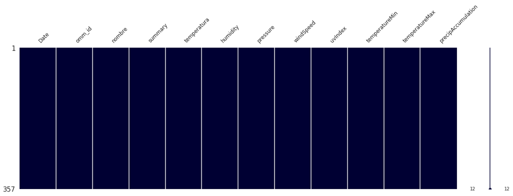

```python
import missingno as msno
msno.matrix(df_riocuarto,figsize=(20, 6), fontsize=12, color=[0,0,0.2])
```

- Del anterior concluimos que la información descargada no presenta valores faltantes.

#### Realizamos las conversiones de unidades necesarias a estos datos para poder compararlos con el dataset "datos_diarios_cordoba.csv".

- Cargamos los datos almacenados en el repositorio - 87453_rio_cuarto.csv
- Para comparar las variables transformamos algunas de las unidades presentes en el conjunto.

```python
# transformaciones de unidades
df_rc['pressure_hpa'] = round(df_rc.pressure * 0.001,3)
df_rc['windSpeed_ms'] = round(df_rc.windSpeed * (1/3.6),3)
df_rc['hydro_year'] = df_rc['Date'].apply(lambda Date: get_hydro_year(Date))
df_rc.sort_values('Date').head(3)
```

|  | Date | omm_id | nombre | summary | temperatura | humidity | pressure | windSpeed | uvIndex | temperatureMin | temperatureMax | precipAccumulation | pressure_hpa | windSpeed_ms | hydro_year |
| --- | --- | --- | --- | --- | --- | --- | --- | --- | --- | --- | --- | --- | --- | --- | --- |
| 0 | 2021-07-01 | Rio Cuarto Aero | 87453 | Clear throughout the day. | 9.635 | 0.45 | 1016.2 | 15.69 | 3 | 0.36 | 18.91 | 0.0240 | 1.016 | 4.358 | 2021 |
| 1 | 2021-07-02 | Rio Cuarto Aero | 87453 | Clear throughout the day. | 11.865 | 0.41 | 1022.9 | 12.56 | 3 | 5.18 | 18.55 | 0.0288 | 1.023 | 3.489 | 2021 |
| 2 | 2021-07-03 | Rio Cuarto Aero | 87453 | Overcast throughout the day. | 11.550 | 0.35 | 1023.1 | 15.77 | 2 | 2.03 | 21.07 | 0.0000 | 1.023 | 4.381 | 2021 |

- Nota 3: al realizar multiples consultas a la pagina tan solo se obtuvieron datos para el año 2021. Para efectos de visualización mostramos la distribución de cada una de las variables obtenidas.

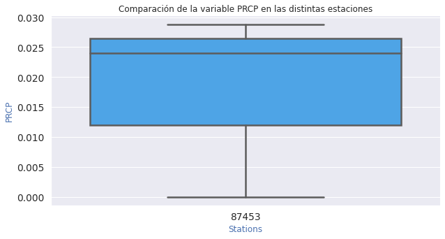

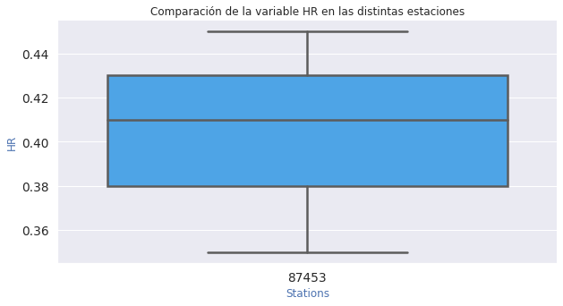

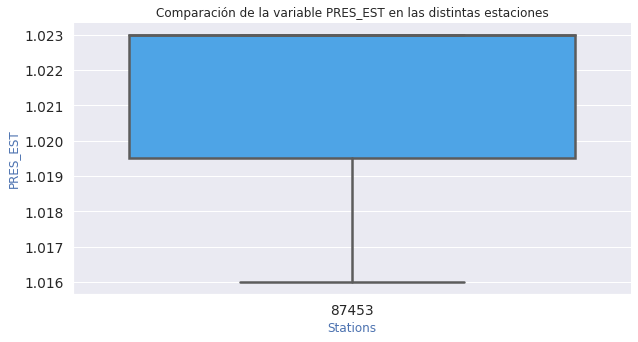

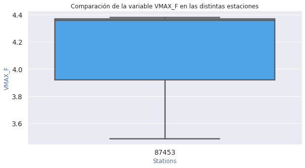

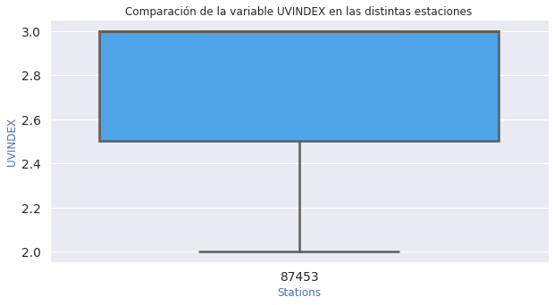

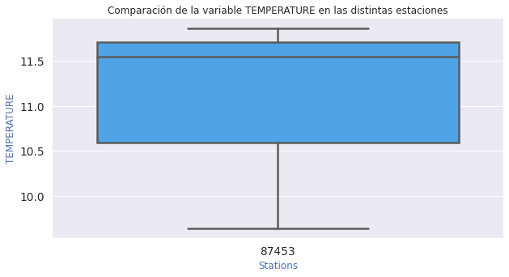

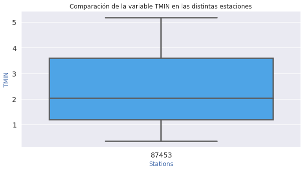

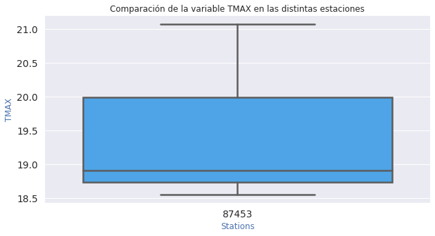

```python
import seaborn as sns

sns.set_theme(style="darkgrid")
sns.set_context("notebook", font_scale=1.25)


BLUE = '#35A7FF'
RED = '#FF5964'
GREEN = '#6BF178'
YELLOW = '#FFE74C'

dataset_with_stations = df_rc2.copy()
not_numeric_cols = ['Date', 'id', 'omm_id', 'nombre', 'hydro_year', 'summary']
numeric_cols = [c for c in dataset_with_stations.columns if c not in not_numeric_cols]


for numeric_col in numeric_cols:
    plt.figure(figsize=(10,5))
    sns.boxplot(data=dataset_with_stations,
                    x='nombre', y=numeric_col,
                    color=BLUE,linewidth=2.5)
    plt.ylabel(numeric_col.upper(), fontsize=12, color='b')
    plt.xlabel('Stations',fontsize=12, color='b')
    plt.title(f'Comparación de la variable {numeric_col.upper()} en las distintas estaciones', fontsize=12)
    #plt.xticks(rotation=90)
    sns.despine()
```

- Importamos el conjunto: datos_diarios_cordoba.csv
- Nota 4: al observar los datos notamos que para la estación 87453, no se presentan registros para los años superiores a 2019.

```python
df_dcor.tail(5)
```

|  | id | omm_id | fecha | helio | hr | nub | prcp | pres_est | pres_nm | td | tmax | tmed | tmin | vmax_d | vmax_f | vmed | caudal | hydro_year |
| --- | --- | --- | --- | --- | --- | --- | --- | --- | --- | --- | --- | --- | --- | --- | --- | --- | --- | --- |
| 249622 | 249623 | 2 | 2017-08-29 | NaN | NaN | NaN | NaN | NaN | NaN | NaN | NaN | NaN | NaN | NaN | NaN | NaN | 49.50303 | 2017 |
| 249623 | 249624 | 2 | 2017-08-30 | NaN | NaN | NaN | NaN | NaN | NaN | NaN | NaN | NaN | NaN | NaN | NaN | NaN | 48.93904 | 2017 |
| 249624 | 249625 | 2 | 2017-08-31 | NaN | NaN | NaN | NaN | NaN | NaN | NaN | NaN | NaN | NaN | NaN | NaN | NaN | 48.33246 | 2017 |
| 249625 | 249626 | 2 | 2017-09-01 | NaN | NaN | NaN | NaN | NaN | NaN | NaN | NaN | NaN | NaN | NaN | NaN | NaN | 47.72549 | 2017 |
| 249626 | 249627 | 2 | 2017-09-02 | NaN | NaN | NaN | NaN | NaN | NaN | NaN | NaN | NaN | NaN | NaN | NaN | NaN | 47.23680 | 2017 |

```python
not_var_cols = ['fecha', 'id', 'omm_id', 'nombre', 'hydro_year', 'summary']
var_cols = [c for c in df_dcor.columns if c not in not_var_cols]
df_dcor_var = df_dcor[var_cols]
df_dcor_var_mean = pd.DataFrame()

for col in var_cols:
    df_dcor_var_mean[col] = df_dcor.groupby(['omm_id','hydro_year'])[col].mean()

df_prueba = df_dcor_var_mean.reset_index()

# df_prueba.loc[(df_prueba['omm_id']==87453) & (df_prueba['hydro_year']==2021), :]
df_prueba.loc[(df_prueba['omm_id']==87453)].tail(5)
```

|  | omm_id | hydro_year | helio | hr | nub | prcp | pres_est | pres_nm | td | tmax | tmed | tmin | vmax_d | vmax_f | vmed | caudal |
| --- | --- | --- | --- | --- | --- | --- | --- | --- | --- | --- | --- | --- | --- | --- | --- | --- |
| 455 | 87453 | 2015 | 6.215015 | 69.571038 | 4.398907 | 2.453279 | 965.577869 | 1014.506557 | 9.753279 | 22.478962 | 16.314481 | 11.105738 | 24.238636 | 13.719318 | 4.223497 | NaN |
| 456 | 87453 | 2016 | 7.231339 | 66.808219 | 3.509589 | 1.531507 | 966.009041 | 1014.930411 | 9.170411 | 23.003343 | 16.503288 | 10.887945 | 21.593607 | 14.936530 | 4.856712 | NaN |
| 457 | 87453 | 2017 | 7.307143 | 63.101370 | 3.542466 | 1.394521 | 965.010685 | 1013.764932 | 8.765479 | 24.134521 | 17.148493 | 11.212958 | 20.986226 | 15.138567 | 5.169863 | NaN |
| 458 | 87453 | 2018 | 6.703562 | 67.200000 | 3.824658 | 2.925753 | 966.067123 | 1015.030685 | 9.107397 | 22.809863 | 16.281370 | 10.777808 | 17.472622 | 13.523343 | 5.056438 | NaN |
| 459 | 87453 | 2019 | 6.493243 | 60.108108 | 3.373874 | 1.942793 | 966.113063 | 1015.218468 | 6.327928 | 22.716667 | 15.455405 | 9.664253 | 18.407407 | 13.020370 | 4.975225 | NaN |

## Terraclimate

Leemos los datos de "TerraClimate.csv" y determinamos para cada variable los valores promedios anuales (correspondiente a cada año hidrológico).

- Leemos los datos del archivo "TerraClimate.csv" y los guardamos en nuestro dataset.

```python
datos_tc = pd.read_csv("https://raw.githubusercontent.com/Rondamon/2022_Mentoria_LluviasExtremas/main/dataset/TerraClimate.csv")
datos_tc
```

|  | Date | Lluvia_mm | ETreal_mm | HumedadSuelo_mm | RadSolar_Wpm2 | Temp_Min | Temp_Max | PresionVapor_hPa | VelViento_mps | IndicePalmer_porc | id | omm_id | nombre |
| --- | --- | --- | --- | --- | --- | --- | --- | --- | --- | --- | --- | --- | --- |
| 0 | 1-Jan-58 | 165.0 | 1570.0 | 32.0 | 281.3 | 15.4 | 29.8 | 19.59 | 3.27 | 0.78 | 5 | 87349 | Pilar Obs. |
| 1 | 1-Feb-58 | 75.0 | 713.0 | 30.0 | 246.3 | 15.8 | 29.5 | 20.88 | 3.08 | -0.45 | 5 | 87349 | Pilar Obs. |
| 2 | 1-Mar-58 | 119.0 | 1123.0 | 33.0 | 213.5 | 13.0 | 26.1 | 17.72 | 3.31 | 0.23 | 5 | 87349 | Pilar Obs. |
| 3 | 1-Apr-58 | 33.0 | 313.0 | 31.0 | 151.6 | 10.7 | 23.3 | 15.13 | 2.65 | -0.46 | 5 | 87349 | Pilar Obs. |
| 4 | 1-May-58 | 13.0 | 119.0 | 28.0 | 109.8 | 6.1 | 19.8 | 10.86 | 2.91 | -0.76 | 5 | 87349 | Pilar Obs. |
| ... | ... | ... | ... | ... | ... | ... | ... | ... | ... | ... | ... | ... | ... |
| 2971 | 1-Aug-19 | 2.0 | 19.0 | 38.0 | 173.9 | 1.5 | 16.2 | 4.24 | 5.15 | -2.08 | 13 | 1 | La Florida |
| 2972 | 1-Sep-19 | 9.0 | 85.0 | 36.0 | 228.0 | 4.2 | 19.1 | 4.79 | 5.50 | -2.74 | 13 | 1 | La Florida |
| 2973 | 1-Oct-19 | 22.0 | 209.0 | 34.0 | 222.7 | 7.1 | 20.8 | 7.46 | 5.97 | -3.75 | 13 | 1 | La Florida |
| 2974 | 1-Nov-19 | 66.0 | 626.0 | 33.0 | 271.1 | 11.5 | 25.8 | 12.12 | 5.77 | -3.96 | 13 | 1 | La Florida |
| 2975 | 1-Dec-19 | 49.0 | 467.0 | 31.0 | 324.7 | 13.3 | 27.3 | 10.65 | 4.52 | -5.01 | 13 | 1 | La Florida |

2976 rows × 13 columns

- Asignamos el año hidrologico correspondinte a cada registro.

```python
datos_tc['Date'] = pd.to_datetime(datos_tc['Date'])
datos_tc['Date'] = datos_tc['Date'].mask(datos_tc['Date'].dt.year > 2019,
                                        datos_tc['Date'] - pd.offsets.DateOffset(years=100))
datos_tc['hydro_year'] = datos_tc['Date'].apply(lambda Date: get_hydro_year(Date))
datos_tc
```

|  | Date | Lluvia_mm | ETreal_mm | HumedadSuelo_mm | RadSolar_Wpm2 | Temp_Min | Temp_Max | PresionVapor_hPa | VelViento_mps | IndicePalmer_porc | id | omm_id | nombre | hydro_year |
| --- | --- | --- | --- | --- | --- | --- | --- | --- | --- | --- | --- | --- | --- | --- |
| 0 | 1958-01-01 | 165.0 | 1570.0 | 32.0 | 281.3 | 15.4 | 29.8 | 19.59 | 3.27 | 0.78 | 5 | 87349 | Pilar Obs. | 1957 |
| 1 | 1958-02-01 | 75.0 | 713.0 | 30.0 | 246.3 | 15.8 | 29.5 | 20.88 | 3.08 | -0.45 | 5 | 87349 | Pilar Obs. | 1957 |
| 2 | 1958-03-01 | 119.0 | 1123.0 | 33.0 | 213.5 | 13.0 | 26.1 | 17.72 | 3.31 | 0.23 | 5 | 87349 | Pilar Obs. | 1957 |
| 3 | 1958-04-01 | 33.0 | 313.0 | 31.0 | 151.6 | 10.7 | 23.3 | 15.13 | 2.65 | -0.46 | 5 | 87349 | Pilar Obs. | 1957 |
| 4 | 1958-05-01 | 13.0 | 119.0 | 28.0 | 109.8 | 6.1 | 19.8 | 10.86 | 2.91 | -0.76 | 5 | 87349 | Pilar Obs. | 1957 |
| ... | ... | ... | ... | ... | ... | ... | ... | ... | ... | ... | ... | ... | ... | ... |
| 2971 | 2019-08-01 | 2.0 | 19.0 | 38.0 | 173.9 | 1.5 | 16.2 | 4.24 | 5.15 | -2.08 | 13 | 1 | La Florida | 2019 |
| 2972 | 2019-09-01 | 9.0 | 85.0 | 36.0 | 228.0 | 4.2 | 19.1 | 4.79 | 5.50 | -2.74 | 13 | 1 | La Florida | 2019 |
| 2973 | 2019-10-01 | 22.0 | 209.0 | 34.0 | 222.7 | 7.1 | 20.8 | 7.46 | 5.97 | -3.75 | 13 | 1 | La Florida | 2019 |
| 2974 | 2019-11-01 | 66.0 | 626.0 | 33.0 | 271.1 | 11.5 | 25.8 | 12.12 | 5.77 | -3.96 | 13 | 1 | La Florida | 2019 |
| 2975 | 2019-12-01 | 49.0 | 467.0 | 31.0 | 324.7 | 13.3 | 27.3 | 10.65 | 4.52 | -5.01 | 13 | 1 | La Florida | 2019 |

2976 rows × 14 columns

- Calculamos la media anual (año hidrologico) de cada una de las variables para cada una de las estaciones de interes.

```python
not_var_cols = ['Date', 'id', 'omm_id', 'nombre', 'hydro_year']
var_cols = [c for c in datos_tc.columns if c not in not_var_cols]
datos_tc_var = datos_tc[var_cols]
datos_tc_var_mean = pd.DataFrame()

for col in var_cols:
  datos_tc_var_mean[col] = datos_tc.groupby(['omm_id','hydro_year'])[col].mean()

datos_tc_var_mean
```

| omm_id | hydro_year | Lluvia_mm | ETreal_mm | HumedadSuelo_mm | RadSolar_Wpm2 | Temp_Min | Temp_Max | PresionVapor_hPa | VelViento_mps | IndicePalmer_porc |
| --- | --- | --- | --- | --- | --- | --- | --- | --- | --- | --- |
| 1 | 1957 | 66.600000 | 632.800000 | 45.400000 | 200.960000 | 8.360000 | 22.320000 | 11.452000 | 3.946000 | -0.054000 |
|  | 1958 | 59.416667 | 564.000000 | 30.666667 | 189.958333 | 5.866667 | 19.916667 | 8.875833 | 4.153333 | 0.305833 |
|  | 1959 | 54.833333 | 519.583333 | 20.666667 | 191.216667 | 5.316667 | 21.208333 | 9.230833 | 4.045833 | 1.140833 |
|  | 1960 | 69.250000 | 643.583333 | 53.916667 | 193.958333 | 5.975000 | 20.766667 | 9.322500 | 4.111667 | 0.762500 |
|  | 1961 | 55.750000 | 533.916667 | 84.416667 | 195.908333 | 6.191667 | 20.650000 | 9.508333 | 4.167500 | 1.642500 |
| ... | ... | ... | ... | ... | ... | ... | ... | ... | ... | ... |
| 87466 | 2015 | 85.833333 | 722.666667 | 165.250000 | 188.975000 | 10.750000 | 23.783333 | 14.811667 | 3.440000 | 0.444167 |
|  | 2016 | 83.416667 | 753.666667 | 209.750000 | 200.050000 | 10.500000 | 23.650000 | 14.382500 | 3.509167 | 2.520000 |
|  | 2017 | 70.916667 | 636.083333 | 185.000000 | 206.616667 | 11.133333 | 24.625000 | 14.662500 | 3.678333 | -0.045000 |
|  | 2018 | 75.916667 | 753.583333 | 158.416667 | 198.408333 | 10.125000 | 23.450000 | 14.905000 | 3.711667 | 0.440833 |
|  | 2019 | 31.857143 | 301.714286 | 47.000000 | 196.514286 | 9.414286 | 22.585714 | 11.555714 | 3.954286 | -2.568571 |

252 rows × 9 columns

- Dado que ambas bases de datos se encuentran en las mismas unidades, no es necesario realizar conversiones.

Determinamos para las estaciones de la cuenca del Carcarañá, los valores promedios anuales (año hidrológico) para comparar los estadísticos de este dataset con los de "datos_diarios_cordoba.csv".